# Similarity of CCL28 fragment hits to other molecules in the fragment screens using Tanimoto fingerprints

```python
import pandas as pd
from rdkit.Chem import AllChem

import os
import pandas as pd
import numpy as np
import matplotlib.pyplot as plt
from matplotlib import gridspec

from rdkit import Chem, DataStructs
from rdkit.Chem.Fingerprints import FingerprintMols
from rdkit.Chem import Draw

# All we need for clustering
from scipy.cluster.hierarchy import dendrogram, linkage
```

# First I will read in an excel file with all of the hits from CCL28, CCL20 and CXCL12 fragment screens

# One of the columnes, labeled smiles, is the smiles string for each fragment in the list.

```python
hits = pd.read_excel('/Users/djensen/Documents/CCL28/CCL28_frag_screen_hits.xlsx', skiprows=2)
hits
```

|  | Cdid | Maybridge ID | Zenobia ID | Enamine ID | Targetmol ID | smiles | Mol | Unnamed: 7 |
| --- | --- | --- | --- | --- | --- | --- | --- | --- |
| 0 | 989.0 | NaN | ZT0784 | NaN | NaN | O=C1Nc2cccc3cccc1c23 | NaN | low mM Affinity |
| 1 | 1007.0 | NaN | ZT0676 | NaN | NaN | Cc1ccc(C(O)=O)c(n1)C(O)=O | NaN | >10mM Affinity, likely pH |
| 2 | 1.0 | NaN | ZT0010 | NaN | NaN | Sc1nc2cc(Cl)ccc2o1 | NaN | low mM Affinity |
| 3 | 968.0 | NaN | ZT0073 | NaN | NaN | OC(=O)c1cc2cc(F)ccc2[nH]1 | NaN | low mM Affinity |
| 4 | 1009.0 | NaN | ZT0716 | NaN | NaN | OC(=O)c1ccccc1C(O)=O | NaN | >10mM Affinity, likely pH |
| 5 | 1000.0 | NaN | ZT0265 | NaN | NaN | Cc1ccc2oc(=O)cc(O)c2c1 | NaN | >10mM Affinity, maybe pH |
| 6 | 1003.0 | NaN | ZT1669 | NaN | NaN | OC(=O)c1cc2ccccc2[nH]1 | NaN | Low mM Affinity, maybe pH |
| 7 | 1005.0 | NaN | ZT0733 | NaN | NaN | Cc1cccc(C(O)=O)c1O | NaN | Low mM Affinity, maybe pH |
| 8 | 1006.0 | NaN | ZT0754 | NaN | NaN | OC(=O)\C=C\c1ccccc1 | NaN | Low mM Affinity, maybe pH |
| 9 | 994.0 | NaN | ZT0262 | NaN | NaN | Oc1cc(=O)oc2ccccc12 | NaN | Low mM Affinity, maybe pH |
| 10 | 998.0 | NaN | ZT0642 | NaN | NaN | OC(=O)c1cccc(I)c1 | NaN | >10mM Affinity, likely pH shifts |
| 11 | 1001.0 | NaN | ZT0707 | NaN | NaN | OC(=O)c1cccc(n1)C(O)=O | NaN | No measureable binding |
| 12 | 1004.0 | NaN | ZT0693 | NaN | NaN | CN(C)c1ccc(cc1)C(O)=O | NaN | Unable to fit titration |
| 13 | 1042.0 | NaN | ZT0586 | NaN | NaN | OC(=O)c1ccc(O)cc1O | NaN | Bad fit, >M affinity |
| 14 | 999.0 | NaN | ZT0588 | NaN | NaN | OC(=O)Cc1ccc(O)c(O)c1 | NaN | Unable to fit titration |
| 15 | 1182.0 | SPB07625 | NaN | NaN | NaN | OCCCCn1cnc2cc(Cl)c(Cl)cc12 | NaN | NaN |
| 16 | 1321.0 | AC40767 | NaN | NaN | NaN | Oc1ccc(O)c2C3CCC(C3)c12 | NaN | Unable to fit titration |
| 17 | 1301.0 | CC39814 | NaN | NaN | NaN | Nc1cccc(c1)-c1cccnc1 | NaN | Unable to fit titration |
| 18 | 1211.0 | CC10501 | NaN | NaN | NaN | OC(=O)c1ccc(s1)-c1ccccc1 | NaN | low mM Affinity |
| 19 | 1205.0 | CC146001 | NaN | NaN | NaN | OC(=O)c1ccc(s1)-c1cccs1 | NaN | low mM Affinity |
| 20 | 1341.0 | NaN | NaN | E2C04.04C11.12C09 | NaN | Cc1cc(Cl)ccc1S(=O)(=O)Nc1ccon1 | NaN | NaN |
| 21 | NaN | NaN | NaN | E2C02.03C11.09C10 | NaN | Cc1csc(n1)C(C#N)C(=O)c1ccccc1F | NaN | NaN |
| 22 | NaN | NaN | NaN | NaN | TA01.A04.02A03 | OC(=O)C1=CC2=C(N1)C=CC(=C2)C(F)(F)F | NaN | NaN |
| 23 | NaN | NaN | NaN | NaN | TD03.E10.03E11 | CC1=CC=C(C=C1)S(=O)(=O)N1N=C(Br)C2=CC=CN=C12 | NaN | NaN |
| 24 | NaN | NaN | NaN | NaN | TD03.F10.03F11 | N[C@@H]1C[C@@H]1F.CC1=CC=C(C=C1)S(O)(=O)=O | NaN | NaN |

## The next section is heavily borrowed and influenced from examples on this page

https://chem-workflows.com/articles/2019/06/28/similarity-analysis-of-compound-databases/

# Create an empty list of molecules, we will append to them as we read through the list of hits.

```python
hit_list = []
```

# Read through the smiles and generate RDkit molecules, append them to the hit_list

```python
counter = 0
for item in hits.smiles:
    mol=Chem.MolFromSmiles(item) # Converting SMILES codes into rdkit mol
    mol.SetProp('_Name', str(hits.Cdid[counter])) # Adding the name for each molecule
    hit_list.append(mol)
    counter = counter + 1
```

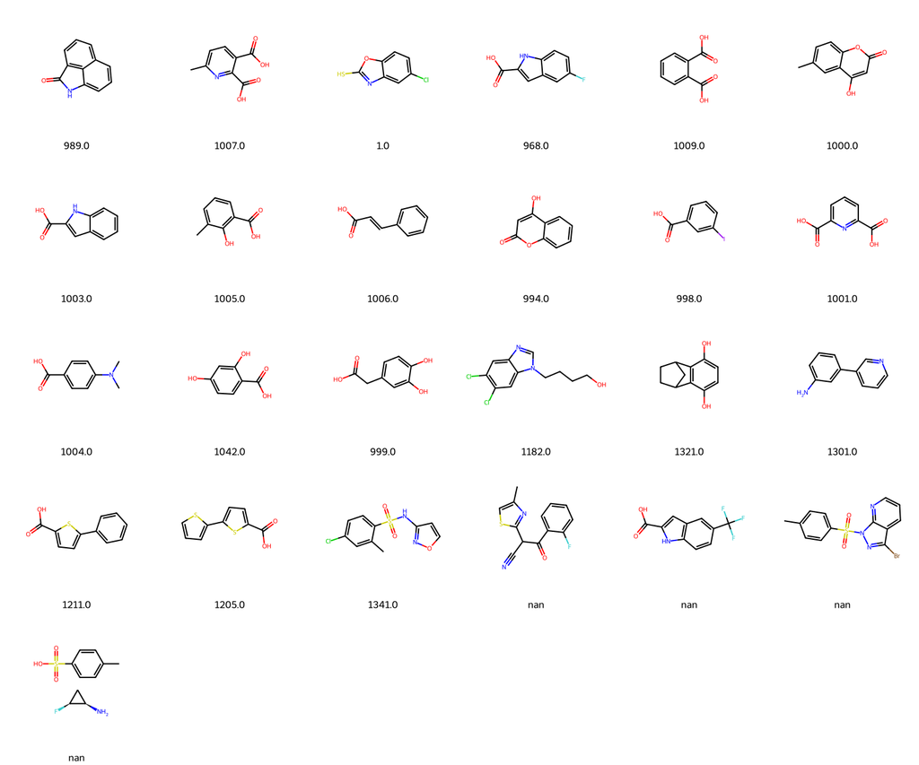

```python
Draw.MolsToGridImage(hit_list,molsPerRow=6,subImgSize=(250,250),legends=[mol.GetProp('_Name') for mol in hit_list])
```

```python
sl = [hit_list[11], hit_list[12]]
sl2 = [hit_list[5], hit_list[9]]
sl3 = [hit_list[16], hit_list[3], hit_list[6]]
sl4 = [hit_list[7], hit_list[10], hit_list[4]]
```

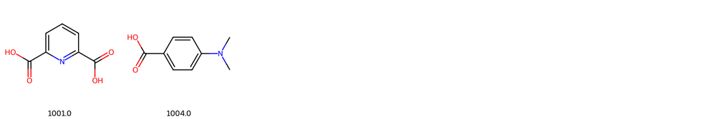

```python
Draw.MolsToGridImage(sl,molsPerRow=6,subImgSize=(250,250),legends=[mol.GetProp('_Name') for mol in sl])
```

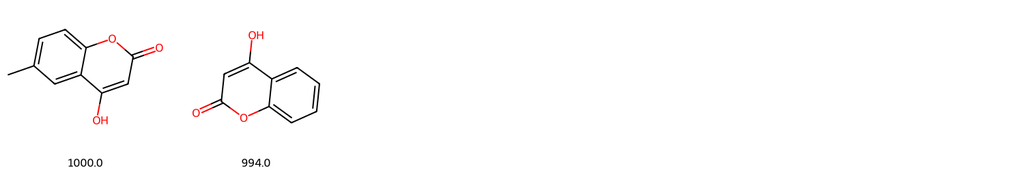

```python
Draw.MolsToGridImage(sl2,molsPerRow=6,subImgSize=(250,250),legends=[mol.GetProp('_Name') for mol in sl2])
```

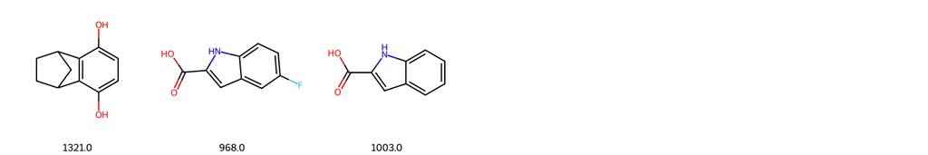

```python
Draw.MolsToGridImage(sl3,molsPerRow=6,subImgSize=(250,250),legends=[mol.GetProp('_Name') for mol in sl3])
```

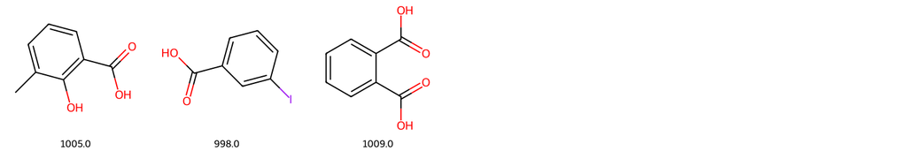

```python
Draw.MolsToGridImage(sl4,molsPerRow=6,subImgSize=(250,250),legends=[mol.GetProp('_Name') for mol in sl4])
```